# TP2 - Econometrics

### 8. Quality check : Explain the type of quality check we have to run to derive a robust conclusion regarding the estimated specification. Run the required quality checks seen during the class. Comment your results

On commence par effectuer un test de Ljung-Box pour tester la dépendance du modèle :

```r
Ljung_box2 <- Box.test(MR, lag = 20, type = "Ljung-Box")
Ljung_box2
```

```
##
##  Box-Ljung test
##
## data:  MR
## X-squared = 18.548, df = 20, p-value = 0.5513
```

> On constate que la p-value du test est supérieure à 0.05. On peut alors affirmer avec un niveau de confiance de 95% que le modèle n’est autocorrélé.

Par la suite :

On considère la RMSE pour estimer l’erreur quadratique moyenne du modèle pour tester la précision de ce dernier.

```r
Rmse <- RMSE(MR,estimated_MR)
Rmse # 0.04465826
```

```
## [1] 0.04465826
```

> On obtient une erreur quadratique moyenne 10 fois plus grande que pour le cas de figure précédent. Ce qui vient confirmer l’hy^pothèse selon laquelle le modèle n’est pas pertinent

### 9. Forecasting : We want to forecast the Stockdata on a monthly basis, over the next three months. Use the required R function available in R to produce the values yt+1,yt+2 and yt+3.

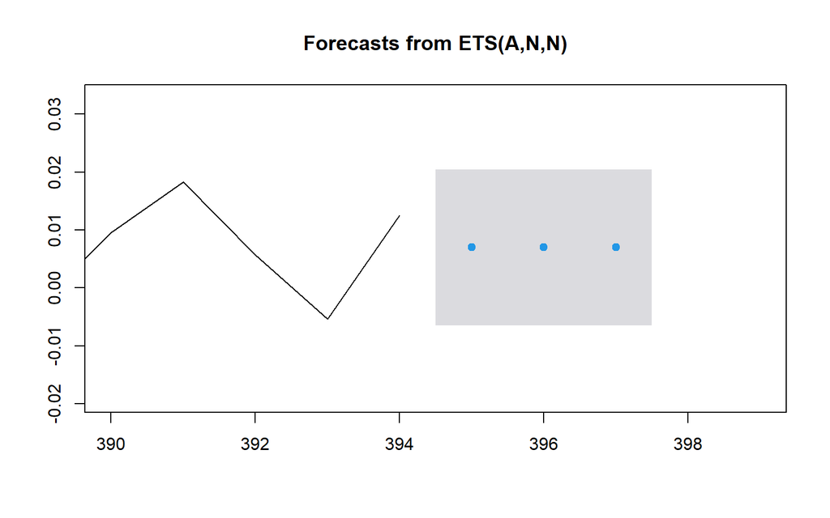

```r
fc2 <- forecast(estimated_MR, level = c(95), h = 3)
plot(fc2, xlim =c(390,399))
```

> On observe cette fois-ci et ce en accord avec les resultats obtenus, que la prédiction semble bancale. En observant l’allure finale de la représentation graphique du US Index, la continuité avec les prédictions ne semble pas cohérente.

En conclusion, on peut observer à travers ces deux études de cas que si une série temporelle est stationnaire, il est possible de la modéliser par un modèle ARMA(p,q) afin de faire des prévisions. En revanche, l’exercice 4 nous laisse supposer que même s’il est possible d’approcher une serie temporelle stationnaire pas un ARMA, l’estimation ne sera pas forcemment la plus précise.